## Predicting the quality of how a barbell lift is executed

The machine learning algorithm below ingests Human Activity Recognition data provided by Groupware@LES at http://groupware.les.inf.puc-rio.br/har and predicts the quality of each exercise’s execution (represented as classifications **A**, **B**, **C**, **D** and **E**) based on accelerometer measurements provided in the data set.

#### Step 1: Data Wrangling

The Groupware data set presents a few challenges: **1)** it is fraught with “#DIV/0!” errors, **2)** it has a preponderance of variables (160) and **3)** many of those variables are sparsely populated. The code below attempts to address these challenges and returns a training data set containing only well-populated numeric variables.

```r
suppressWarnings(library(caret))
```

```r
suppressWarnings(library(ggplot2))

set.seed(666)

# Load training data and clean out "#DIV/0!" errors
train.start <- read.table('data/pml-training.csv',sep=',', header=T, stringsAsFactors=F)
x <- readLines('data/pml-training.csv')
y <- gsub( "\"#DIV/0!\"", "NA", x )
cat(y, file="data/clean.train.csv", sep="\n")

# Load cleaned training data and testing data
train.clean <- read.table('data/clean.train.csv',sep=',', header=T, stringsAsFactors=F)
test.quiz <- read.table('data/pml-testing.csv',sep=',', header=T, stringsAsFactors=F)

# identify the purely numeric covariates
nums <- sapply(train.clean, is.numeric)
train <- train.clean[,nums]
test.quiz <- test.quiz[,nums]

# remove index and timestamp columns
train <- train[, c(-1:-4)]
test.quiz <- test.quiz[, c(-1:-4)]

# remove the near-zero variables
nsv <- nearZeroVar(train,saveMetrics=TRUE)
train <- train[,!nsv$zeroVar]
test.quiz <- test.quiz[,!nsv$zeroVar]

# remove columns that are more than 50% NA
test.quiz <- test.quiz[ , apply(train, 2, function(x) (length(which(is.na(x)==F))/length(x)) > .5)]
train <- train[ , apply(train, 2, function(x) (length(which(is.na(x)==F))/length(x)) > .5)]
```

The number of variables in the train and test.quiz data sets are now **reduced from 160 to 52**.

#### Step 2: Data Slicing and Predictor Plotting

The training data set is divided into a **train.set** and **test.set**, the eventual machine learning algorithm will train on the former and be run once against the latter to establish in-sample and out-of-sample errors, respectively.

```r
# split data
train<-cbind(train, train.clean$classe)
names(train)[ncol(train)] <- 'classe'

train.partition <- createDataPartition(y=as.character(train.clean$classe), p=.75, list=F)

train.set <- train[train.partition,]
test.set <- train[-train.partition,]
train.classe <- train.set$classe
test.classe <- test.set$classe
train.set <- train.set[,-ncol(train.set)]
test.set <- test.set[,-ncol(test.set)]
```

52 is still an intimidating number of variables. So taking inspiration from machine learning algorithms that sample and resample data sets, I ran multiple pairs plots against randomly chosen subsets of my training data to glimpse potential relationships. **Figure 1** below is a sample of one of those pairs plots.

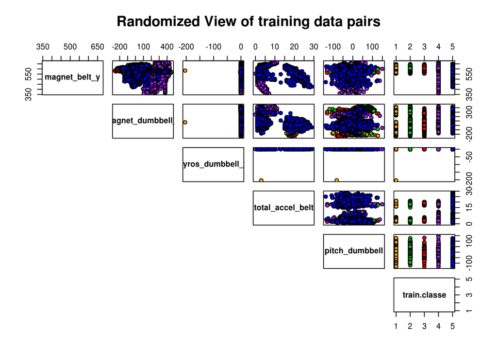

```r
# re-align predictors with outcomes
train.qplot <- cbind(train.set, train.classe)

# create pair plots
pairs(train.qplot[,c(sample(1:ncol(train.qplot[,-ncol(train.qplot)]), 5), ncol(train.qplot))],
      main = "Randomized View of training data pairs", pch = 21,
      bg = c("orange", "green3", "red", "purple", "blue")[unclass(train.qplot$train.classe)],
      lower.panel=NULL, font.labels=2, cex.labels=1.0)
```

One thing I notice is that not much variation in the response is explained by these predictors, nor are there any obvious linear relationships, and some of the predictors have very significant outliers. **Figure 2** further confirms this with an example of some of the relationships I found when examining specific predictors.

```r
require(gridExtra)
```

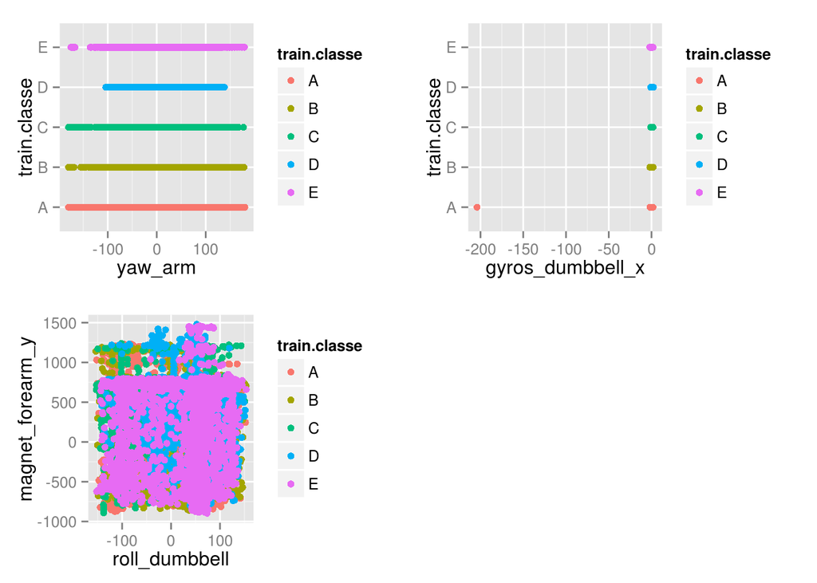

```r
plot1 <- qplot(yaw_arm, train.classe, data=train.qplot, colour=train.classe)
plot2 <- qplot(gyros_dumbbell_x, train.classe, data=train.qplot, colour=train.classe)
plot3 <- qplot(roll_dumbbell, magnet_forearm_y, data=train.qplot, colour=train.classe)
grid.arrange(plot1, plot2, plot3, ncol=2, nrow=2)
```

#### Step 3: Pre-Processing

To address any NA’s that may exist in my data and further reduce the number of predictors, I chose to pre-process all my data sets with knnImpute and Principal Component Analysis. **Figure 3** is a feature plot of the resulting train.pca data set.

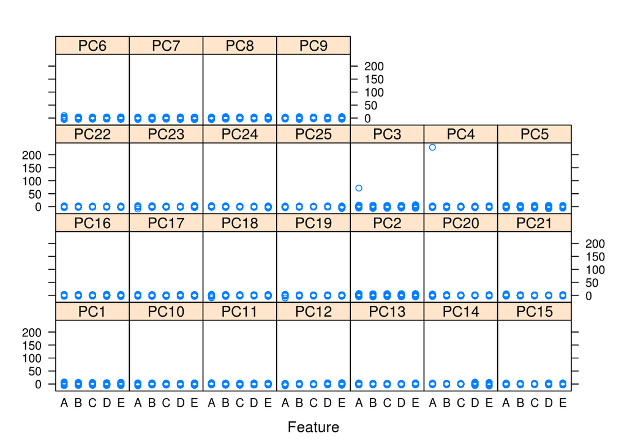

```r
preProc <- preProcess(train.set, method=c("knnImpute"))
train.knn <- predict(preProc, train.set)
test.knn <- predict(preProc, test.set)
test.quiz.knn <- predict(preProc, test.quiz)
prePCA <- preProcess(train.knn, method="pca")
train.pca <- predict(prePCA, train.knn)
test.pca <- predict(prePCA, test.knn)
test.quiz.pca <- predict(prePCA, test.quiz.knn)

# Feature Plot of train.pca
featurePlot(train.pca, train.classe)
```

Though the number of predictors is cut in half, the data set now loses interpretability. And it’s clear that there do remain, in two extreme cases, some outliers in the data.

#### Step 4: Fit Models and Predict

Being as there did not appear to be any clear linear relationships among my initial predictors, I model fitting with a decision tree algorithm (**achieving only 32% accuracy**), then a linear discriminant analysis model (**52%**). I had the most success though with **bagging**.

```r
tc <- trainControl(method="cv", number=5)
modFit <- train(train.pca, train.classe, method="treebag", trControl=tc)
pred <- predict(modFit, test.pca)
acc <- mean(pred == test.classe)
```

Tree-bagging achieves an in-sample error of roughly **5%**. I would expect this to be a fairly good estimate of the out-of sample error, given that I employed **5-fold cross-validation** which estimates the error of the model by dividing the **train.pca** data set into five different sets of training and testing data sets and then applies the model against them, returning 5 different error estimates. An average of those estimates is then used as the model’s estimated error.

And it turns out indeed to be a pretty accurate estimate. When run against my **test.pca** data set, my model’s resulting out-of-sample error is **4%**.

```r
table(pred,test.classe)
```

```
##     test.classe
## pred    A    B    C    D    E
##    A 1366   31    7    6    0
##    B   10  888   13    2    9
##    C    7   18  821   40   12
##    D   10    5   10  754   12
##    E    2    7    4    2  868
```